# Pickleball Matched Pairs Solutions

Read in the Dataset:

```r
library(readr)
library(dplyr)
library(ggplot2)
library(tidyr)

pickleBall <- read_csv("pickleBall.csv")
```

## 1 - Creating a boxplot

1. Create a boxplot comparing Singles and Doubles Reliability scores.

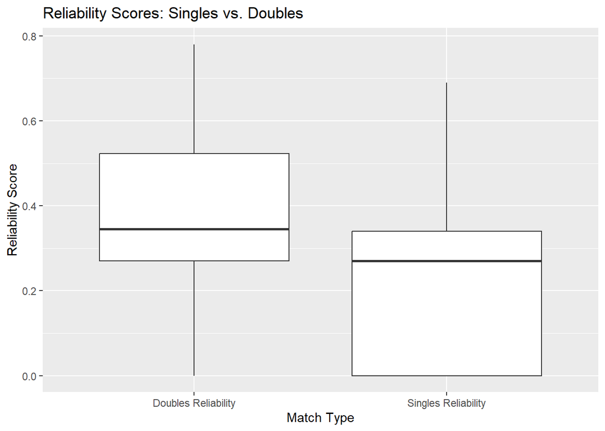

```r
pickle <- pickleBall |> select(2,3, 7, 9, 12)

pickle_long <- pivot_longer(pickle, cols = c(3, 4), names_to = "Category", values_to = "Reliability")

ggplot(data = pickle_long, aes(x = Category, y = Reliability)) +
  geom_boxplot() +
  labs(title = "Reliability Scores: Singles vs. Doubles",
       x = "Match Type",
       y = "Reliability Score")
```

2. What do you notice about the center, spread, and any outliers in the distributions? Which category appears to have a higher average reliability?

The mean for doubles reliability appears to be higher than for singles reliability, indicating that players tend to be more reliable in doubles matches. The spread (or variability) is larger for singles, which suggests that singles reliability scores vary more from player to player. There are no apparent outliers in either distribution based on the boxplot.

We want to perform a hypothesis test to test if there is a significant difference between singles and doubles reliability. Because each player was measured twice (single and double reliability), we want to use a matched pairs t-test to perform the hypothesis test.

## 2 - Checking conditions

1. Create a new column labeled `Difference` that takes Doubles Reliability minus Singles Reliability.

```r
pickleBall$Difference <- pickleBall$`Doubles Reliability` - pickleBall$`Singles Reliability`
```

2. State and evaluate the three conditions needed for a paired t-test. You may assume independence. Use code to help justify normality and check for outliers.

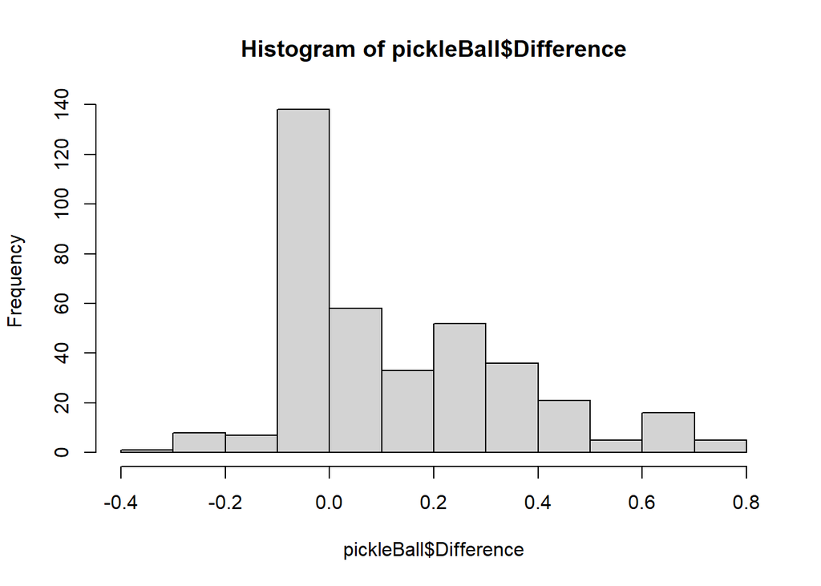

```r
hist(pickleBall$Difference)
```

1. Independence: Data was collected independently.
2. Normality: The differences between the pairs slightly right skewed but since the same size is 380 it sould still be safe to use the t-distribution.
3. No Extreme Outliers: The differences should not have any extreme outliers.

## 3 - Performing a matched pairs hypothesis test manually.

Let $\mu$ be the true mean difference (Doubles - Singles) - because doubles reliability mean is higher than singles reliability.

1. State the null and alternative hypothesis.

Null Hypothesis: The mean difference between the paired observations is zero. Alternative Hypothesis: The mean difference is not zero.

2. Calculate the mean difference of the `Difference` column. Report your result.

```r
mean_difference <- mean(pickleBall$Difference)
mean_difference
```

```
[1] 0.1454211
```

The mean difference between doubles reliability and singles reliability is 0.145

3. Calculate the standard deviation of the `Difference` column. Report your result.

```r
sd_difference <- sd(pickleBall$Difference)
sd_difference
```

```
[1] 0.212845
```

The standard deviation of the difference between doubles reliability and singles reliability is 0.213.

4. Calculate the t-statistic. The formula is below in which you can do it by hand or do it using r. Report your result.
   $$t = \frac{\bar{D}}{s_D / \sqrt{n}}$$

```r
t_stat <- mean_difference / (sd_difference / sqrt(380))
t_stat
```

```
[1] 13.31851
```

The t-statistic is 13.319.

5. Calculate the degrees of freedom. Report your result.

```r
dfree <- 380 - 1
dfree
```

```
[1] 379
```

The degrees of freedom is 379.

6. Calculate the p-value for two-tailed hypothesis. To do this do in R code - 2 * pt(-abs(t-statistic), df = degrees of freedom). Report your result.

```r
p_value <- 2 * pt(-abs(t_stat), df = dfree)
p_value
```

```
[1] 1.828055e-33
```

The p-value is 0

7. Use the p-value to make a conclusion.

There is strong evidence (p-value = 0, 13.319, df = 379) that there is a difference in means between doubles reliability and singles reliability.

A possible explanation for this is that doubles matches are more commonly played than single matches.

We can also do this process using the t.test function in r which allows us to perform the hypothesis test quicker.

## 4 - Performing a matched pairs hypothesis test using R function:

1. Perform a matched pairs hypothesis t-test using the `t.test()` function and setting `paired = TRUE`. Include all parts of a formal hypothesis test.

```r
pairedt_test <- t.test(pickleBall$`Doubles Reliability`, pickleBall$`Singles Reliability`, paired = TRUE)
pairedt_test
```

```
    Paired t-test

data:  pickleBall$`Doubles Reliability` and pickleBall$`Singles Reliability`
t = 13.319, df = 379, p-value < 2.2e-16
alternative hypothesis: true mean difference is not equal to 0
95 percent confidence interval:
 0.1239522 0.1668899
sample estimates:
mean difference
      0.1454211
```

Null Hypothesis: The mean difference between the paired observations is zero. Alternative Hypothesis: The mean difference is not zero.

Reject the null hypothesis.

There is strong evidence (p-value < 2.2e-16, t = 13.319, df = 379) that there is a difference in means between doubles reliability and singles reliability.

2. Interpret the confidence interval results given in the output in part A.

With 95% confidence, the mean reliability score for players as doubles is between 0.124 and 0.167 higher than for singles. Since zero is not in the interval, the difference is statistically significant.